# Preparación de los datos: algas

Equipo CAL: Carlos Petricioli, Amanda Balderas, Liliana Millán

Noviembre 2014

# Verificación de la base

## Tamaño

Se muestra la dimensión de la base.

```
## [1] 200  19
```

La base contiene 200 registros para cada una de las 18 variables y su id.

## Estructura

Se muestra la estructura de la base.

```
## Classes 'tbl_df', 'tbl' and 'data.frame':    200 obs. of  19 variables:
##  $ temporada: Factor w/ 4 levels "autumn","spring",..: 4 2 1 2 1 4 3 1 4 4 ...
##  $ tamanio  : Factor w/ 3 levels "large","medium",..: 3 3 3 3 3 3 3 3 3 3 ...
##  $ velocidad: Factor w/ 3 levels "high","low","medium": 3 3 3 3 3 1 1 1 3 1 ...
##  $ mxph     : num  8 8.35 8.1 8.07 8.06 8.25 8.15 8.05 8.7 7.93 ...
##  $ mno2     : num  9.8 8 11.4 4.8 9 13.1 10.3 10.6 3.4 9.9 ...
##  $ c1       : num  60.8 57.8 40 77.4 55.4 ...
##  $ no3      : num  6.24 1.29 5.33 2.3 10.42 ...
##  $ no4      : num  578 370 346.7 98.2 233.7 ...
##  $ opo4     : num  105 428.8 125.7 61.2 58.2 ...
##  $ po4      : num  170 558.8 187.1 138.7 97.6 ...
##  $ chla     : num  50 1.3 15.6 1.4 10.5 ...
##  $ a1       : num  0 1.4 3.3 3.1 9.2 15.1 2.4 18.2 25.4 17 ...
##  $ a2       : num  0 7.6 53.6 41 2.9 14.6 1.2 1.6 5.4 0 ...
##  $ a3       : num  0 4.8 1.9 18.9 7.5 1.4 3.2 0 2.5 0 ...
##  $ a4       : num  0 1.9 0 0 0 0 3.9 0 0 2.9 ...
##  $ a5       : num  34.2 6.7 0 1.4 7.5 22.5 5.8 5.5 0 0 ...
##  $ a6       : num  8.3 0 0 0 4.1 12.6 6.8 8.7 0 0 ...
##  $ a7       : num  0 2.1 9.7 1.4 1 2.9 0 0 0 1.7 ...
##  $ id       : int  1 2 3 4 5 6 7 8 9 10 ...
```

# Identificación de variables

No se cuenta con variables `risk` ni `costo` identificadas en esta base. Se considera como variables `target` a las correspondientes a la información sobre distribución de algas (a1, a2, a3, a4, a5, a6 y a7). Se identifica el nombre de la variable correspondiente al id.

# Variables a ignorar

Vamos a guardar en una variable, los nombres de las columnas que se van a ignorar en el entrenamiento del modelo.

### IDs y variables de salida

Tenemos que la base no cuenta con variables `risk` ni `costo`.

```
## [1] "id"
```

Por el momento sólo tenemos la variable “id” como variable a ignorar.

### Constantes y valores únicos por observación

Se van a ignorar aquellas variables que contengan un único valor en todas las observaciones. Se tiene que la base no tiene variables con un valor único en todas las observaciones.

```
## [1] "id"
```

En este momento tenemos que la única variable a ignorar es el “id” de la base.

### Faltantes

Vamos a identificar las variables con valores faltantes, se observa que la base no cuenta con variables que tengan un 70% o más de valores faltantes.

```
## [1] "id"
```

Así tenemos un nuevo listado de variables a ignorar.

Variables con más faltantes: en chla el 6% de sus datos son faltantes, cl el 5% de sus datos son faltantes.

```
## temporada   tamanio velocidad      mxph      mno2        c1       no3
##       0.0       0.0       0.0       0.5       1.0       5.0       1.0
##       no4      opo4       po4      chla        a1        a2        a3
##       1.0       1.0       1.0       6.0       0.0       0.0       0.0
##        a4        a5        a6        a7        id
##       0.0       0.0       0.0       0.0       0.0
```

### Variable de salida (`target`)

Si el problema de minado, es supervisado, removemos las observaciones que tengan `NA` en la variable `target`.

Vemos si se modificaría la dimensión de la base al eliminar NA’s de las variables `target`. En este caso observamos que no cambiaría la base.

```
## [1] 200  19
```

```
## [1] 200  19
```

Si el problema es de clasificación, hay que convertir la variable `target` a categórica. En este caso este paso no aplica.

Mostramos la distribución (esto nos indicará si el problema no está balanceado).

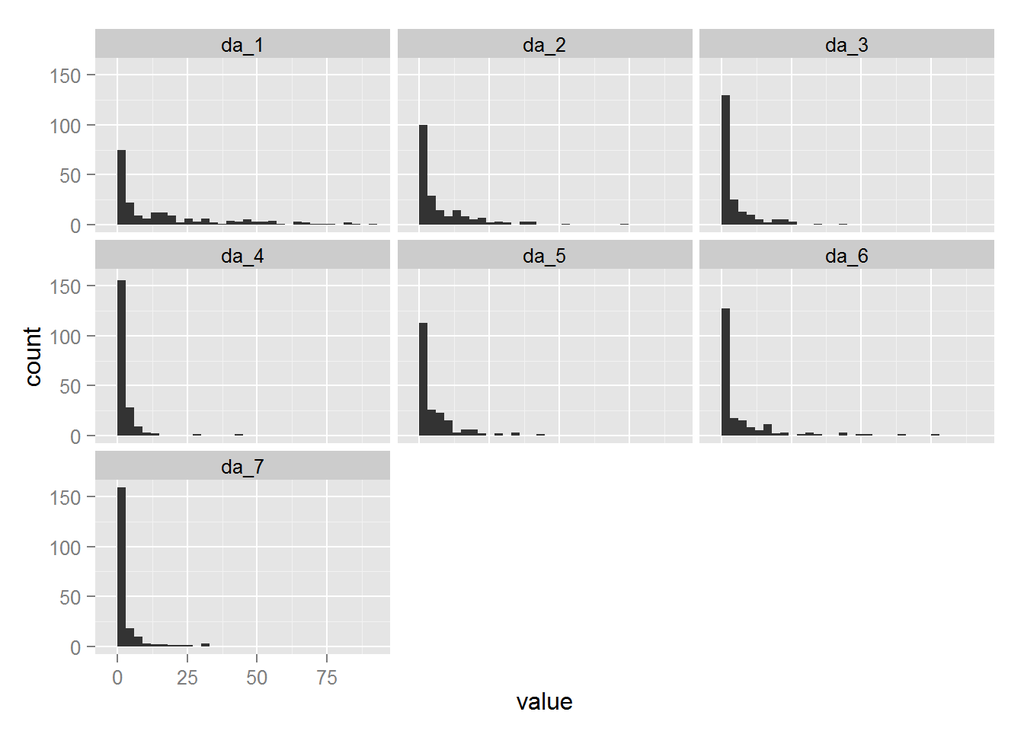

Tambiénn se muestran las variables target en boxplot.

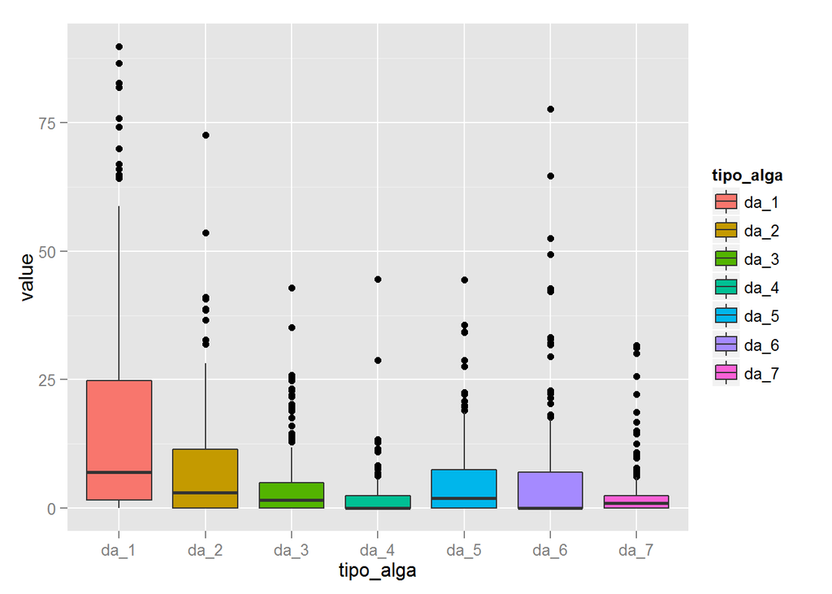

# Variables correlacionadas

Identificamos las variables muy correlacionadas. Se tiene que no hay variables con correlación mayor a 0.95.

```
## [1] var1 var2 cor
## <0 rows> (or 0-length row.names)
```

```
## [1] "id"
```

Se agregan las variables a ignorar por alta correlación, en este caso no se tienen variables altamente correlacionadas.

# Valores faltantes

La estrategia a seguir será eliminar las observaciones cuyos valores tengan más del 20% de NAs. Aquellas que tienen menos del 20% los valores de NAs se modificarán a través de una regresión lineal, media/mediana/moda dependiendo de la distribución de cada variable.

De la correlación entre faltantes:

Los faltantes en la opo4 y no4 están correlacionados positivamente al 100% al igual que los faltantes en opo4 y no3, esto significa que cuando falta un valor en nopo4 también falta en no3 y no4. La correlación entre chla y c1 también es alta positivamente más del 75%.

[output not shown]

```
##   temporada tamanio velocidad mxph mno2 c1 no3 no4 opo4 po4 chla a1 a2 a3
## 1         0       0         0    0    0  0   0   0    0   0    0  0  0  0
## 2         0       0         0    0    0  0   0   0    0   0    0  0  0  0
## 3         0       0         0    0    0  0   0   0    0   0    0  0  0  0
## 4         0       0         0    0    0  0   0   0    0   0    0  0  0  0
## 5         0       0         0    0    0  0   0   0    0   0    0  0  0  0
## 6         0       0         0    0    0  0   0   0    0   0    0  0  0  0
##   a4 a5 a6 a7 id
## 1  0  0  0  0  0
## 2  0  0  0  0  0
## 3  0  0  0  0  0
## 4  0  0  0  0  0
## 5  0  0  0  0  0
## 6  0  0  0  0  0
```

```
##           mxph      mno2       c1       no3       no4      opo4       po4
## mxph  1.000000 -0.007125 -0.01626 -0.007125 -0.007125 -0.007125 -0.007125
## mno2 -0.007125  1.000000  0.20751  0.494949  0.494949  0.494949 -0.010101
## c1   -0.016263  0.207514  1.00000  0.438086  0.438086  0.438086  0.207514
## no3  -0.007125  0.494949  0.43809  1.000000  1.000000  1.000000  0.494949
## no4  -0.007125  0.494949  0.43809  1.000000  1.000000  1.000000  0.494949
## opo4 -0.007125  0.494949  0.43809  1.000000  1.000000  1.000000  0.494949
## po4  -0.007125 -0.010101  0.20751  0.494949  0.494949  0.494949  1.000000
## chla -0.017910  0.186207  0.81145  0.397805  0.397805  0.397805  0.186207
##          chla
## mxph -0.01791
## mno2  0.18621
## c1    0.81145
## no3   0.39781
## no4   0.39781
## opo4  0.39781
## po4   0.18621
## chla  1.00000
```

[figure not shown]

Otra forma de visualizar si los valores faltantes entre las diferentes variables están correlacionados.

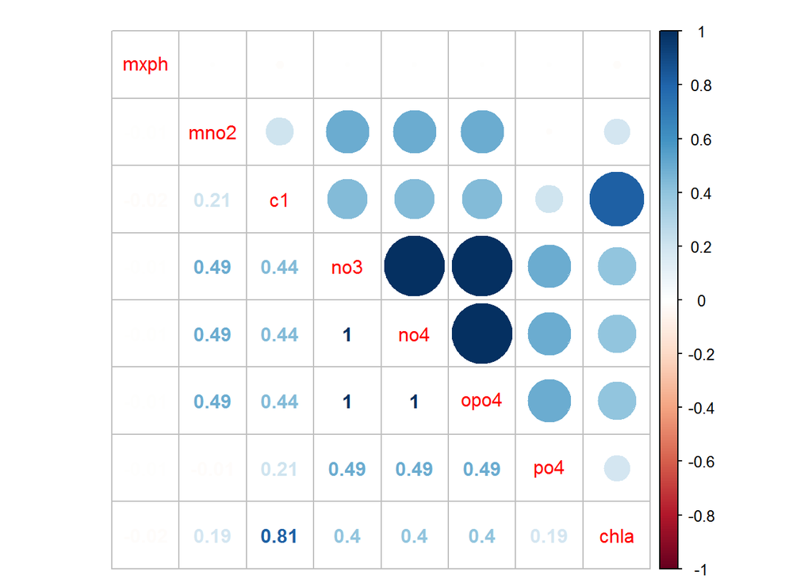

Identificamos las observaciones con variables faltantes y cuáles podrían ser omitidas. Para lo anterior consideramos que se omitirán aquellas observaciones que tengan un 20% de variables faltantes.

```
## [1] "El no. de observaciones con algún NA es: 16"
```

```
## [1] "Las observaciones con algún NA son:"
```

```
## Source: local data frame [16 x 19]
##
##     temporada tamanio velocidad mxph mno2    c1   no3 no4    opo4     po4
## 28     autumn   small      high 6.80 11.1 9.000 0.630  20   4.000      NA
## 38     spring   small      high 8.00   NA 1.450 0.810  10   2.500   3.000
## 48     winter   small       low   NA 12.6 9.000 0.230  10   5.000   6.000
## 55     winter   small      high 6.60 10.8    NA 3.245  10   1.000   6.500
## 56     spring   small    medium 5.60 11.8    NA 2.220   5   1.000   1.000
## 57     autumn   small    medium 5.70 10.8    NA 2.550  10   1.000   4.000
## 58     spring   small      high 6.60  9.5    NA 1.320  20   1.000   6.000
## 59     summer   small      high 6.60 10.8    NA 2.640  10   2.000  11.000
## 60     autumn   small    medium 6.60 11.3    NA 4.170  10   1.000   6.000
## 61     spring   small    medium 6.50 10.4    NA 5.970  10   2.000  14.000
## 62     summer   small    medium 6.40   NA    NA    NA  NA      NA  14.000
## 63     autumn   small      high 7.83 11.7 4.083 1.328  18   3.333   6.667
## 116    winter  medium      high 9.70 10.8 0.222 0.406  10  22.444  10.111
## 161    spring   large       low 9.00  5.8    NA 0.900 142 102.000 186.000
## 184    winter   large      high 8.00 10.9 9.055 0.825  40  21.083  56.091
## 199    winter   large    medium 8.00  7.6    NA    NA  NA      NA      NA
## Variables not shown: chla (dbl), a1 (dbl), a2 (dbl), a3 (dbl), a4 (dbl),
##   a5 (dbl), a6 (dbl), a7 (dbl), id (int)
```

```
## [1] "¿Cuántos NAs hay por observación?"
```

```
##   [1] 0 0 0 0 0 0 0 0 0 0 0 0 0 0 0 0 0 0 0 0 0 0 0 0 0 0 0 1 0 0 0 0 0 0 0
##  [36] 0 0 1 0 0 0 0 0 0 0 0 0 1 0 0 0 0 0 0 2 2 2 2 2 2 2 6 1 0 0 0 0 0 0 0
##  [71] 0 0 0 0 0 0 0 0 0 0 0 0 0 0 0 0 0 0 0 0 0 0 0 0 0 0 0 0 0 0 0 0 0 0 0
## [106] 0 0 0 0 0 0 0 0 0 0 1 0 0 0 0 0 0 0 0 0 0 0 0 0 0 0 0 0 0 0 0 0 0 0 0
## [141] 0 0 0 0 0 0 0 0 0 0 0 0 0 0 0 0 0 0 0 0 1 0 0 0 0 0 0 0 0 0 0 0 0 0 0
## [176] 0 0 0 0 0 0 0 0 1 0 0 0 0 0 0 0 0 0 0 0 0 0 0 6 0
```

```
## [1] "Las observaciones con más de dos NAs son:"
```

```
## Source: local data frame [2 x 19]
##
##     temporada tamanio velocidad mxph mno2 c1 no3 no4 opo4 po4 chla   a1
## 62     summer   small    medium  6.4   NA NA  NA  NA   NA  14   NA 19.4
## 199    winter   large    medium  8.0  7.6 NA  NA  NA   NA  NA   NA  0.0
## Variables not shown: a2 (dbl), a3 (dbl), a4 (dbl), a5 (dbl), a6 (dbl), a7
##   (dbl), id (int)
```

```
## [1] 198  19
```

# Imputación de valores faltantes

En el caso de las observaciones que no serán omitidas pero que cuentan con algún NA se realizará una imputación de acuerdo al tipo y comportamiento de la variable.

Verificando la distribución de datos para las variables numéricas para obtener la mejor estrategia para imputar los valores faltantes.

```
## temporada   tamanio velocidad      mxph      mno2        c1       no3
##  "factor"  "factor"  "factor" "numeric" "numeric" "numeric" "numeric"
##       no4      opo4       po4      chla        a1        a2        a3
## "numeric" "numeric" "numeric" "numeric" "numeric" "numeric" "numeric"
##        a4        a5        a6        a7        id
## "numeric" "numeric" "numeric" "numeric" "integer"
```

```
## [1] 1600    2
```

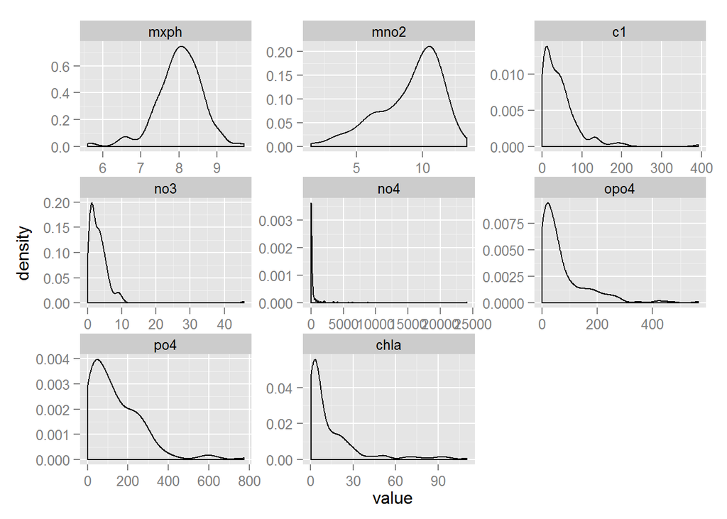

También mostramos las numéricas en boxplots, en no4 se identifica que hay un outlier muy ‘grande’

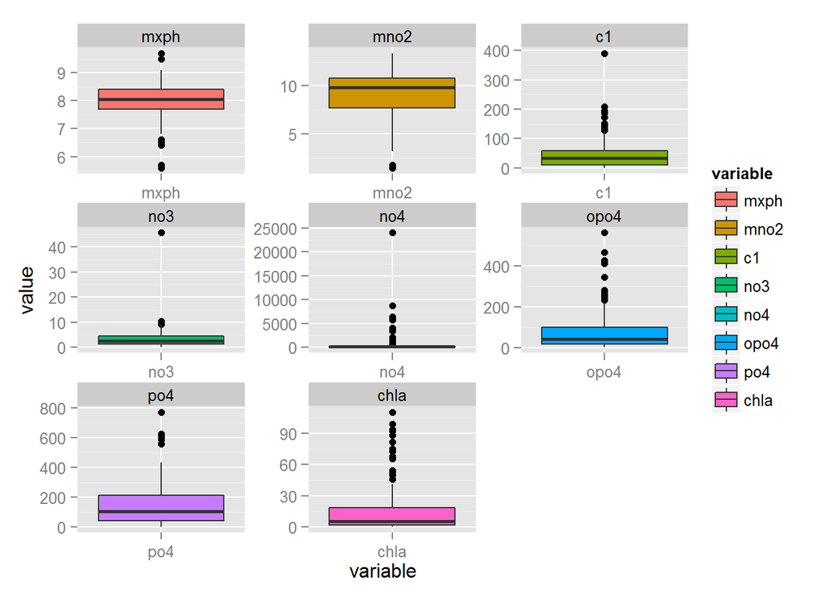

## Imputación en variables categóricas

En el caso de tener observaciones con NA en alguna variable categorica, se crearía una nueva variable donde se asignaría a los NA a un nuevo `level`. En nuestro caso no tenemos variables categóricas cono NA’s.

## Imputación: Central

En el caso de variables numéricas podemos realizar diferentes tipos de imputaciones, una de ellas es asignando una medida central a los datos faltantes, esta medida puede ser, la media, mediana, etc.

En este ejemplo vamos a realizar una imputación utilizando la media.

```
## named integer(0)
```

Al verificar nuestra nueva base, observamos que se realizaron las imputaciones correspondientes, ya que la nueva base ahora no cuenta con valores faltantes.

## Imputación: Correlación

Otro tipo de imputación es utilizando la correlación de variables mediante una regresión lineal para obtener los valores para los datos faltantes.

```
## named integer(0)
```

Al verificar nuestra nueva base, observamos que se realizaron las imputaciones correspondientes, ya que la nueva base ahora no cuenta con valores faltantes. Es importante tomar en cuenta que se debe verificar variables independientes elegidas para la regresión, deben contar con dato para la misma observación que se desea imputar.

## Imputación: Similitud

```
##   c1 chla
##    6   11
```

Podemos observar que hay variables en las cuales no se realiza la imputación, dado que en las observaciones correspondientes hay otra u otras variables que también tienen valores faltantes, por lo que no se puede obtener la distancia correspondiente, por lo anterior se deberá tener cuídado en cuántas variables pueden quedar con valores faltantes en cada observación, o realizar otro tipo de imputación.

# Identificación de Variables

Guardamos la información que utilizaremos para definir nuestros modelos.

### Apéndice: Ambiente